# WhoLivesMarkdown

This brief examines the 2021 demographic data released by the U.S. Census Bureau covering race, ethnicity, and age. For results of the official 2020 Census headcount see our analyses under https://www.datacenterresearch.org/topic/population-demographics/. This brief also covers 2021 estimates from the Census Bureau’s annual American Community Survey (ACS) on a range of important topics such as educational attainment, poverty, and housing costs.

The U.S. Census Bureau estimates that 1,261,726 residents were living in metro New Orleans as of July 2021, a 6 percent increase from April 2010.[^1] The metro area now has 94 percent of its 2000 population of 1,337,726. In this brief, we examine demographic data released by the U.S. Census Bureau and identify important changes in metro area parishes since 2000 (or the best benchmark available).

## Race/Ethnicity

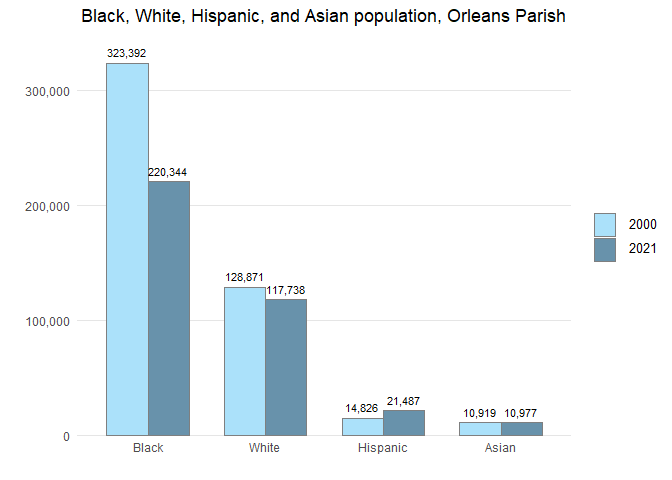

**Source**: The Data Center analysis of U.S. Census Bureau data from Census 2000 and Population Estimates 2021.

### What is Orleans Parish?

Orleans Parish is the city of New Orleans. New Orleans and Orleans Parish are interchangeable. Their boundaries are the same, and they contain the same population.

In Orleans Parish, the share of the 2021 population that is Black — while lower than in 2000 when it was 67 percent — continues to represent the majority of city residents at 58 percent. The share of Hispanic residents in the city increased from 3 percent in 2000 to 6 percent in 2021; the share of Asian residents increased from 2 percent to 3 percent; and the share of White increased from 27 percent to 31 percent. Meanwhile, Hispanic, Asian, and Black populations increased as a share of the total population in Jefferson, St. Bernard, St. Charles, St. John the Baptist, and St. Tammany parishes. In fact, the number and share of Hispanics have increased in all eight parishes in the metro area since 2000.

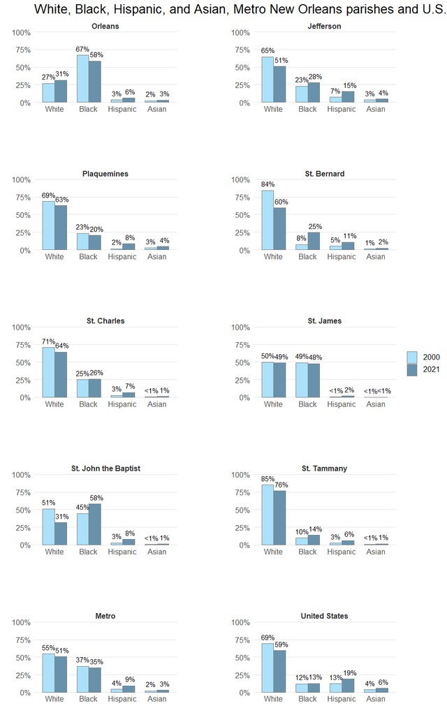

**Source**: The Data Center analysis of U.S. Census Bureau data from Census 2000 and Population Estimates 2021.

Between 2000 and 2021, the number of Hispanics in Jefferson Parish increased by 33,789 reaching over 15 percent of the total parish population. Orleans Parish and St. Tammany Parish gained 6,661 and 12,046 Hispanics, respectively, such that the Hispanic share of the population grew to 6 percent in Orleans and 6 percent in St. Tammany by 2021.

As of July 2021, there were 118,295 Hispanics in the metro area, representing 9 percent of the metro population. This is up from 2000 when there were 58,545, representing 4 percent of the metro population. Despite these recent gains, the Hispanic share of the population in metro area parishes is below the average for the United States, which has grown from 13 percent to 19 percent of the total U.S. population over these 21 years.

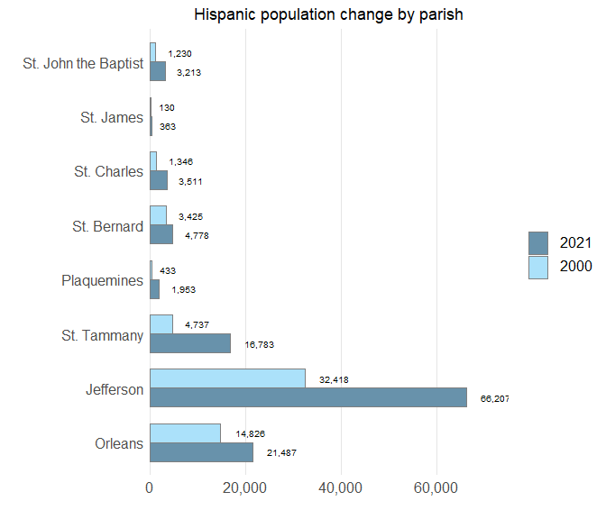

**Source**: The Data Center analysis of U.S. Census Bureau data from Census 2000 and Population Estimates 2021.

The number of Hispanics in the New Orleans metro has grown every year since 2006. Indeed, while the overall metro population has grown 6 percent since 2010, the Hispanic population has grown 28 percent such that Hispanics account for 36 percent of the metro’s population growth since 2010.

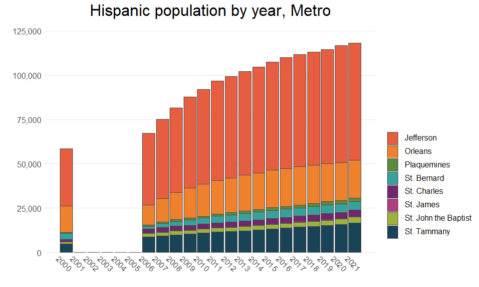

**Source**: The Data Center analysis of U.S. Census Bureau data from Census 2000, 2010, Intercensal Estimates 2006-2009, and Population Estimates 2011-2021.

Hispanic is an umbrella term comprising multiple nationalities and ethnicities. Researchers have shown that most Hispanics prefer to identify by nationality rather than by pan-ethnic terms such as “Hispanic” and “Latino.”[^3] The nationalities of Hispanics residing in metro New Orleans are quite distinct from the national Hispanic profile.

In 2021, the largest Hispanic group in metro New Orleans was Honduran, representing 32 percent of the Hispanic population. In comparison, Hondurans represent only 2 percent of the national Hispanic population. These figures point to metro New Orleans as a hub of Honduran migration.

Not to be ignored, the Mexican population represents 13 percent of the Hispanic population in metro New Orleans. Nevertheless, the Mexican population is much less prominent in the metro than nationally, where it represents 60 percent of the Hispanic population.

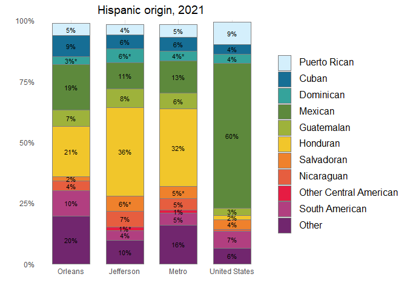

∗ = Difference between indicated measure and the U.S. is not significant at 95% confidence interval.

**Source**: The Data Center analysis of U.S. Census Bureau data from American Community Survey 2021.

## Population by age and household types

The progression of the baby boomers through the age groups, along with falling birth rates, has brought massive changes to the metro — and indeed the whole country — with many more changes yet to come.[^4] Looking at the total population in the metro by five-year age groups for 2000 and 2021, the baby boomers are like a demographic tidal wave. Consequently, the median age of the metro has risen to 38.8 in 2021 from 34.8 in 2000.

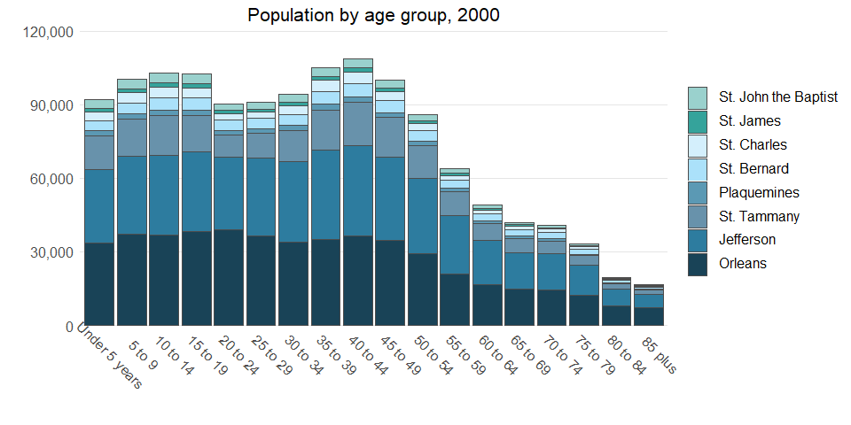

**Source**: The Data Center analysis of U.S. Census Bureau data from Census 2000.

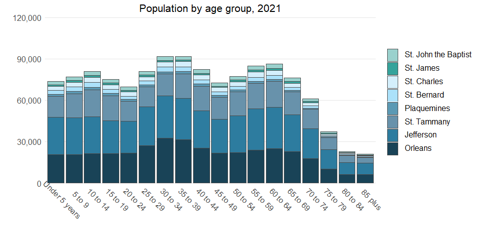

**Source**: The Data Center analysis of U.S. Census Bureau data from Population Estimates 2021.

Meanwhile, the share of households with children is shrinking while the share of individuals living alone is growing — both across the metro and nation. As of 2021, 24 percent of households in metro New Orleans included children, down from 34 percent in 2000. Between 2000 and 2021, the percent of St. Tammany households with children declined from 40 percent to 31 percent; the percent of Jefferson households with children declined from 33 percent to 24 percent; and the percent of Orleans households with children declined from 30 percent to 19 percent.

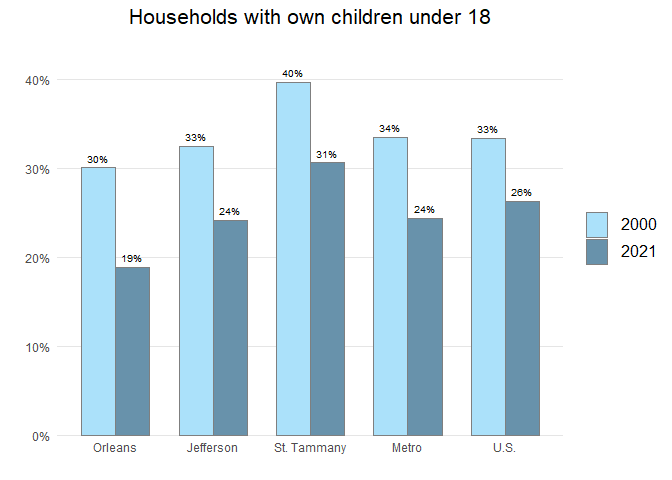

**Source**: The Data Center analysis of U.S. Census Bureau data from Census 2000 SF3 and American Community Survey 2021.

As households with children have declined, the share of single-person households has grown in the metro and nationwide. The metro area share of individuals living alone grew from 27 percent in 2000 to 34 percent in 2021 — similar to the trend for Jefferson Parish where the share of householders living alone grew from 27 percent to 33 percent. The increase was larger in Orleans Parish, which jumped from 33 to 45 percent.

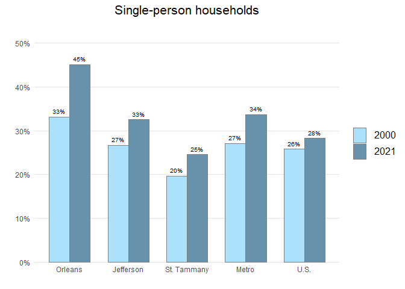

**Source**: The Data Center analysis of U.S. Census Bureau data from Census 2000 SF3 and American Community Survey 2021.

While the metro has regained much of the post-Katrina population losses, youth population is substantially lower than pre-Katrina levels. The metro had 358,092 children under 18 years in 2000 and only 279,805 in 2021. Much of this loss was driven by Orleans Parish, where the population under 18 has declined to 74,460 from 129,408. The under 18 population is now 22 percent of the metro population, down from 27 percent in 2000.

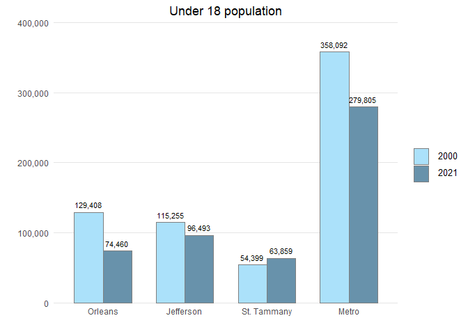

**Source**: The Data Center analysis of U.S. Census Bureau data from Census 2000 and Population Estimates 2021.

### Where is data for Plaquemines, St. Bernard, St. James, St. Charles, and St. John the Baptist?

Although race/ethnicity and age data is available for all eight parishes in metro New Orleans, most other demographic data (such as educational attainment, poverty, and homeownership) is available for only the three most populous parishes of Jefferson, Orleans, and St. Tammany, as well as the metro.

## Educational attainment, income, and internet access

Educational attainment is an important determinant of household incomes, workforce skills, and regional resiliency.[^5] In New Orleans, 42 percent of adults 25 and older had at least a bachelor’s degree in 2021 - higher than the U.S. average of 35 percent, and up from 26 percent in 2000. The overall metro area share of adults with a bachelor’s degree grew from 23 to 34 percent - lower than the national average of 35 percent.

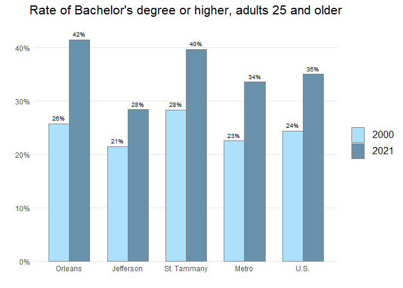

**Source**: The Data Center analysis of U.S. Census Bureau data from Census 2000 SF3 and American Community Survey 2021.

The share of New Orleans adults who have a bachelor’s degree has grown across racial and ethnic groups since 1980. But while 69 percent of White adults in New Orleans have a bachelor’s, only 23 percent of Black adults have a bachelor’s as of 2021. The share of White adults in Orleans Parish who have a bachelor’s degree is substantially higher than the U.S. or metro area overall: 69 percent of White adults in New Orleans have a bachelor’s degree while that number is 44 percent or lower in neighboring parishes and the nation. Only 20 and 19 percent of Black adults have a bachelor’s degree or higher in Jefferson and St. Tammany, respectively.

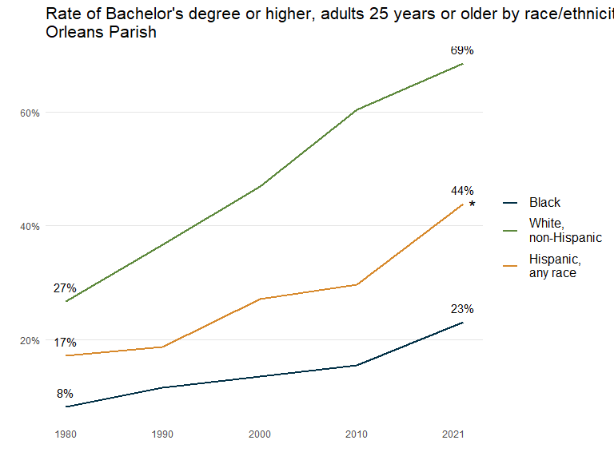

**Notes**: The number of Asians in New Orleans during the timespan of this chart is too small to produce reliable statistics. 1980 data for White educational attainment is inclusive of Hispanic people (due to data source limitations).  
∗ = Change in time is not significant for Hispanic for 2000-2010.

**Source**: The Data Center analysis of U.S. Census Bureau data from 1980, 1990, 2000 SF3, and 2010 and American Community Survey 2021.

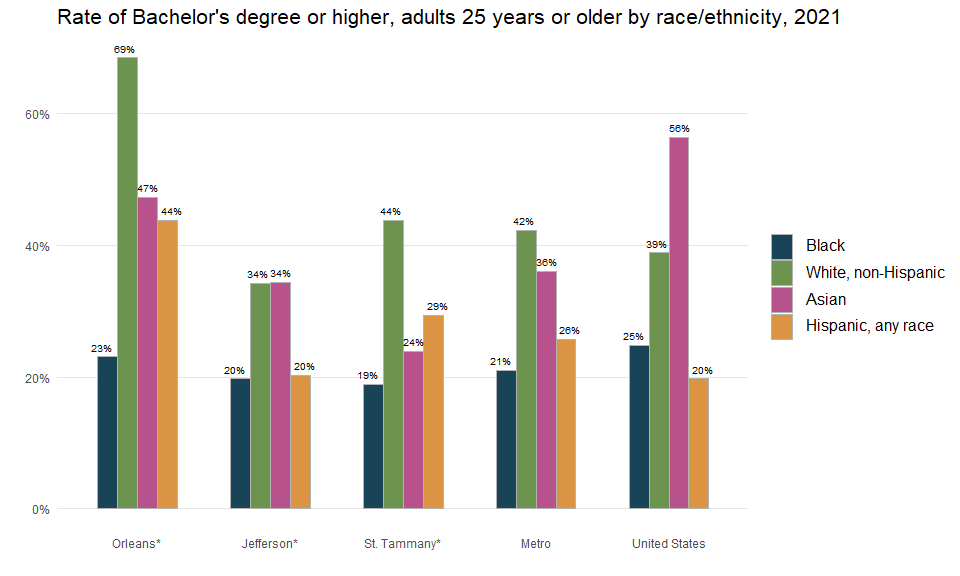

∗ = In Orleans Parish, the difference between Hispanic and Asian is not statistically significant.  
∗ = In Jefferson Parish, the difference between White and Asian and Black and Hispanic is not statistically significant.  
∗ = In St. Tammany Parish, the difference between Black and Hispanic, Black and Asian, and Hispanic and Asian is not statistically significant.

**Source**: The Data Center analysis of U.S. Census Bureau data from American Community Survey 2021.

The metro area increase in the share of adults with a bachelor’s degree or higher has been coupled with a decline in the share of adults with less than a high school degree. The proportion of adults 25 years and older with less than a high school education declined across all three of the largest parishes, leading to a metro-wide decrease from 15 percent in 2000 to 12 percent in 2021. In the city of New Orleans, the share of adults with less than a high school degree fell from 25 percent to 10 percent.

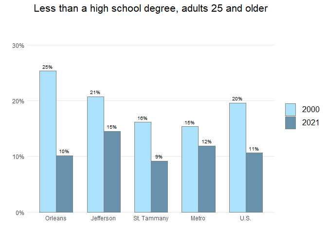

**Source**: The Data Center analysis of U.S. Census Bureau data from Census 2000 SF3 and American Community Survey 2021.

The 2021 median household income of $56,837 for the metro, $56,282 for Jefferson Parish, and $46,942 for the city of New Orleans are significantly lower than the U.S. median of $69,717.

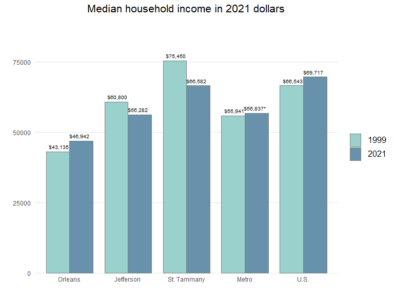

∗ = Difference between 1999 and 2021 is not significant at 95% confidence interval.

**Source**: The Data Center analysis of U.S. Census Bureau data from Census 2000 SF3 and American Community Survey 2021.

In 1979, households with higher incomes were disproportionately in the parishes surrounding New Orleans, while lower income White, Hispanic, and Black households were more likely to live in the city.[^6] By 2021, these patterns had changed with higher income White households more often living in the city such that income disparity within the city has escalated. In 2021, Black households in New Orleans had a median income of only $30,292, while Hispanic households were at $60,358 and White households at $83,727.

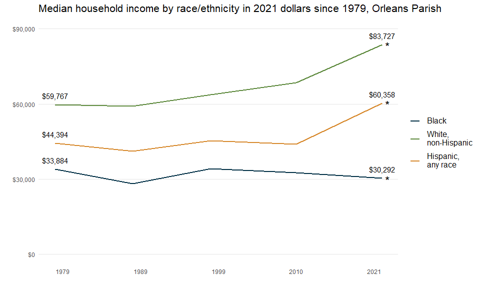

**Notes**: The number of Asians in New Orleans during the timespan of this chart is too small to produce reliable statistics. ∗ = Change in time is not significant for Black for 2010-2021.  
∗ = Change in time is not significant for any race for 1999-2010.

**Source**: The Data Center analysis of U.S. Census Bureau data from 1980, 1990, 2000 SF3, and 2010 and American Community Survey 2021.

In 2021, Black households in New Orleans have incomes 64 percent less than White households. In St. Tammany, Black households have a median income of $52,849 which is 27 percent less than White households in that parish. In Jefferson, Black households have a median income of $40,168 which is 37 percent less than White households in that parish. Hispanic households have a median of $58,930 across the metro which is relatively consistent across the 3 large parishes.

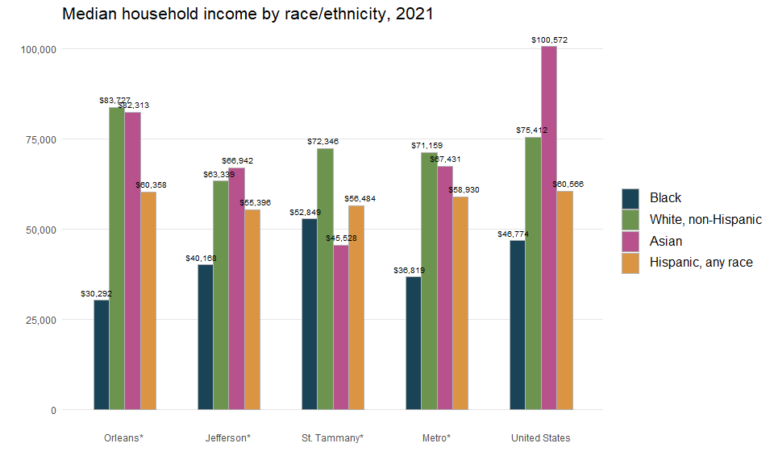

∗ = In Orleans Parish, the difference between White and Asian is not statistically significant.  
∗ = In Jefferson Parish, the difference between White and Asian, White and Hispanic, and Hispanic and Asian is not statistically significant.  
∗ = In St. Tammany Parish, the difference between White and Asian, White and Hispanic, Black and Hispanic, Black and Asian, and Hispanic and Asian is not statistically significant.  
∗ = In the New Orleans Metro Area, the difference between White and Asian and Hispanic and Asian is not statistically significant.

**Source**: The Data Center analysis of U.S. Census Bureau data from American Community Survey 2021.

Internet access is an important indicator of access to information. Studies have shown that without broadband, computer access, and encompassing technology training services, workers and students are at a disadvantage in the job market and education system.[^7] Only 71 percent of households in Orleans Parish and only 76 percent of households in Jefferson Parish are connected to the internet through a home-based internet service, such as broadband (cable, DSL, or fiber), satellite, or dial-up service, compared to 79 percent nationwide. St. Tammany is above the national average at 84 percent of households connected to the internet by a home-based service internet connection. Internet access without a subscription refers to households that only have access through group access locations such as school, work, a library, or coffee shop.

An increasingly common way to access the internet is through a smartphone or some other cellular device. While, in general, smartphone access contributes positively to lessening the Digital Divide, having access only through a smartphone restricts ability to fully leverage the internet to complete common tasks such as writing and researching a resume, registering your kids for school, analyzing data about your neighborhood, or creating content for an internet business. In Orleans Parish, 13 percent of households only have access through a smartphone, compared to 11 percent nationwide.

### What is the Digital Divide?

Inequalities between individuals, households, businesses, or geographic areas with regard to access, use of, or impact of information and communication technologies.

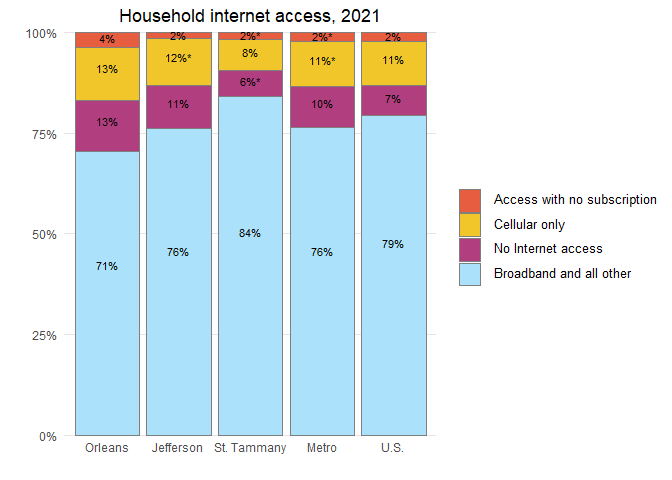

∗ = Difference between indicated measure and the U.S. is not significant at 95% confidence interval.

**Notes**: Access with no subscription refers to those who receive free internet from their housing environment (e.g. college dorms).

**Source**: The Data Center analysis of U.S. Census Bureau data from American Community Survey 2021.

## Poverty and access to vehicles

A high share of residents living below the poverty level indicates the economy is not providing many residents with the ability to meet their most basic needs, including food, housing, and transportation. The poverty rate in New Orleans decreased from 28 to 25 percent between 1999 and 2021 while the Jefferson Parish poverty rate increased from 14 to 17 percent. Across the U.S., the poverty rate increased by one percentage point between 1999 and 2021.

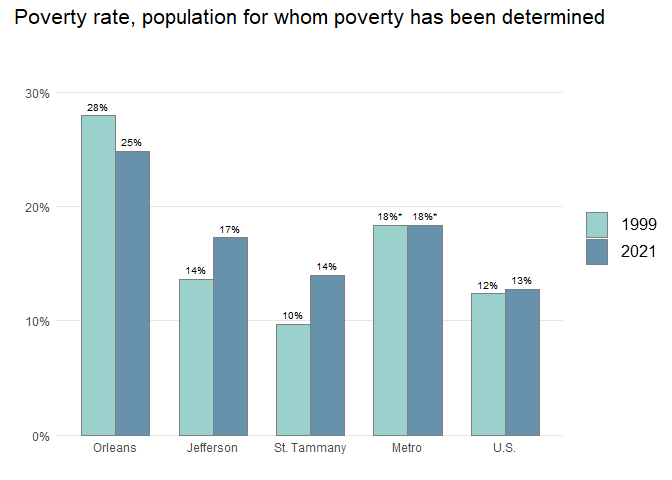

∗ = Difference between 1999 and 2021 is not significant at 95% confidence interval.

**Source**: The Data Center analysis of U.S. Census Bureau data from Census 2000 SF3 and American Community Survey 2021.

### How is poverty measured?

The Census still uses the federal definition for poverty that was first created in 1964. The original calculations were based on studies from the early 1960s that indicated that family food costs were about one-third of a family’s budget. But housing costs have risen much faster than food costs since 1964. Also, the current calculations don’t count non-cash government aid, like Child Tax Credits or housing subsidies, as income. And they aren’t adjusted for differences in costs of living in different parts of the country. Given these limitations, the Census began publishing a Supplemental Poverty Measure that incorporates up-to-date data on regional housing costs as well as several kinds of government aid. According to the Census, the 2020 Supplemental Poverty Rate for the U.S. was 9.1 percent. The Official Poverty Rate that same year was 11.4 percent.[^8] The Census Bureau does not calculate Supplemental Poverty Rates for geographies smaller than the nation as a whole.[^9]

The poverty rate for Black New Orleanians spiked when the 1980s “oil bust” hit, jumping from 37% in 1979 to 42% in 1989. White New Orleanians were not similarly affected. The poverty rate for White New Orleanians remained at roughly 12% in 1979 and in 1989. Large disparities in the poverty rate continue to be evident at all geographic levels. For example, in metro New Orleans 29 percent of Black people and 19 percent of Hispanic people live in poverty compared to 11 percent of White people and 19 percent of Asian people.[^10]

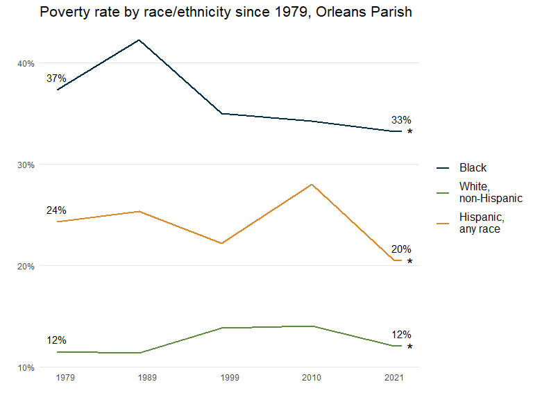

**Notes**: The number of Asians in New Orleans during the timespan of this chart is too small to produce reliable statistics. 1980 data for White poverty rates is inclusive of Hispanic people (due to data source limitations). ∗ = Change in time is not significant for any race for 2000-2021 or 2010-2021.  
∗ = Change in time is not significant for Black and Hispanic for 2000-2010.

**Source**: The Data Center analysis of U.S. Census Bureau data from 1980, 1990, 2000 SF3, and 2010 and American Community Survey 2021.

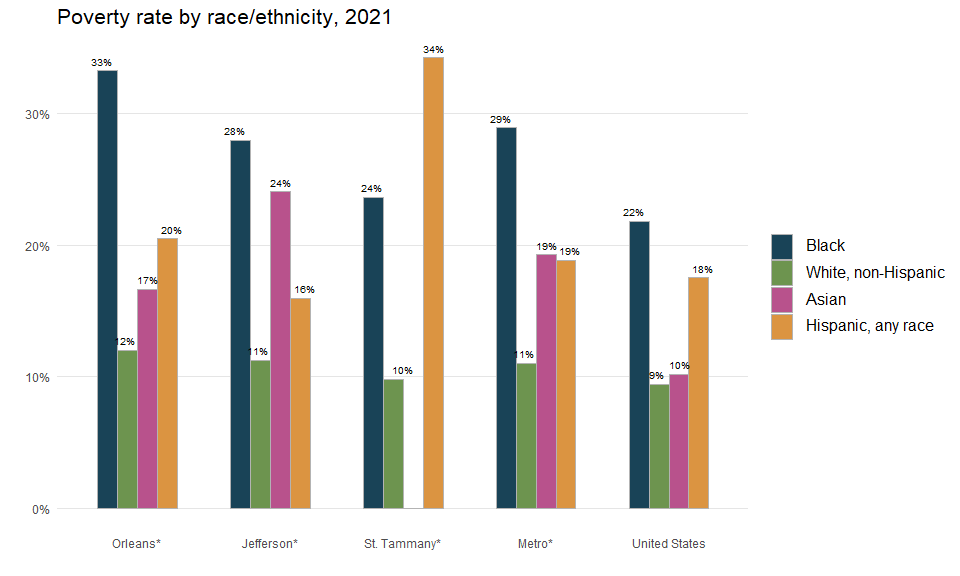

∗ = In Orleans Parish, the difference between White and Asian and Hispanic and Asian is not statistically significant.  
∗ = In Jefferson Parish, the difference between White and Hispanic, Black and Asian, and Hispanic and Asian is not statistically significant.  
∗ = In New Orleans Metro Area, the difference between Hispanic and Asian is not statistically significant.

**Source**: The Data Center analysis of U.S. Census Bureau data from American Community Survey 2021.

Like the overall poverty rate, the child poverty rate in New Orleans decreased between 1999 and 2021. The child poverty rate of across the Metro area in 2021 is higher than the U.S. child poverty rate.

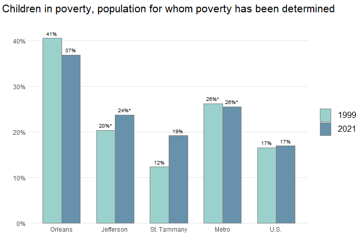

∗ = Difference between 1999 and 2021 is not significant at 95% confidence interval.

**Source**: The Data Center analysis of U.S. Census Bureau data from Census 2000 SF3 and American Community Survey 2021.

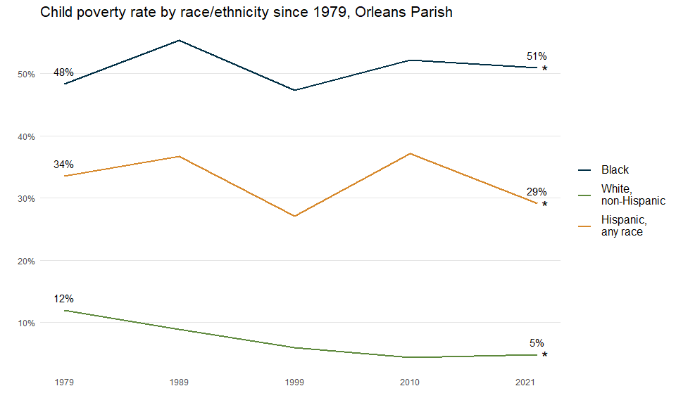

**Notes**: The number of Asians in New Orleans during the timespan of this chart is too small to produce reliable statistics. 1980 data for White child poverty is inclusive of Hispanic people (due to data source limitations).  
∗ = Change in time is not significant for any race for 2000-2021 or 2010-2021.  
∗ = Change in time is not significant for White or Hispanic for 2000-2010.

**Source**: The Data Center analysis of U.S. Census Bureau data from 1980, 1990, 2000 SF3, and 2010 and American Community Survey 2021.

Orleans Parish’s very low rate of 5 percent child poverty for White children stands in stark contrast to the 51 percent rate for Black children. While in Orleans, poverty rates for Black children are 10 times higher than for White children, in Jefferson Parish Black children experience poverty at a little over 3 times higher rates than White children – which is a disparity on par with the national average. In metro New Orleans, 26 percent of Hispanic children live in poverty – statistically no different from the national rate.

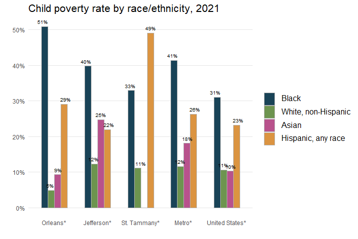

∗ = In Orleans Parish, the difference between White and Asian and Hispanic and Asian is not statistically significant.  
∗ = In Jefferson Parish, the difference between White and Asian, Black and Asian, and Hispanic and Asian is not statistically significant.  
∗ = In the New Orleans Metro Area, the difference between White and Asian and Hispanic and Asian is not statistically significant.  
∗ = In United States, the difference between White and Asian is not statistically significant.

**Source**: The Data Center analysis of U.S. Census Bureau data from Census 2000 SF3 and American Community Survey 2021.

Post-Katrina, the share of New Orleans households without access to a vehicle dropped from 27 percent in 2000 to 17 percent in 2021. Nonetheless, at 17 percent, New Orleans’ share is more than twice as high as in neighboring parishes, indicating the importance of a robust public transportation system and comprehensive evacuation plan.

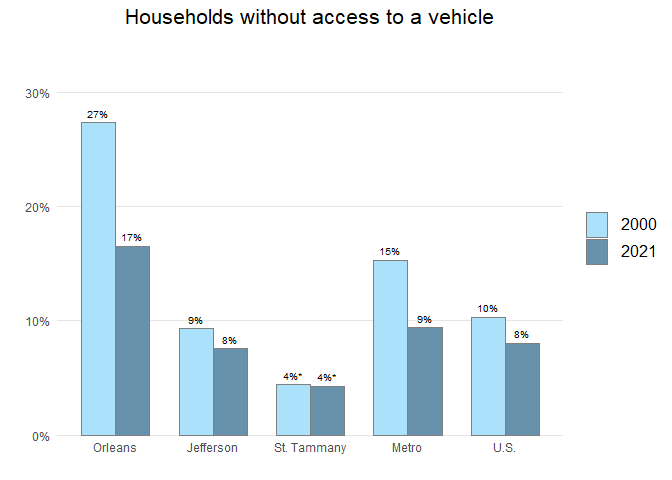

∗ = Difference between 1999 and 2021 is not significant at 95% confidence interval.

**Source**: The Data Center analysis of U.S. Census Bureau data from Census 2000 SF3 and American Community Survey 2021.

## Foreign-born population and geographic mobility

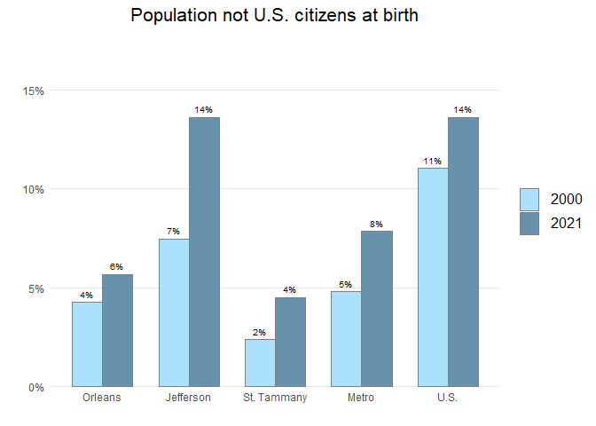

**Source**: The Data Center analysis of U.S. Census Bureau data from Census 2000 SF3 and American Community Survey 2021.

Like the foreign-born population, a rising share of the population who moved into Orleans Parish in the past year may reflect expanding economic opportunities. The most frequent reason people move long distances, such as from one state to another state, is for job opportunities.[^12] In addition, the young and well-educated are more likely than others to move long distances.[^13] In 2021, 6 percent of the population in Orleans Parish had moved into the parish in the past year, up from 3 percent in 2004. Over 59 percent of the new movers into Orleans Parish came from outside the state of Louisiana. In Jefferson Parish, the share of the population who were new movers into the parish was 5 percent in 2004 and has not significantly changed.

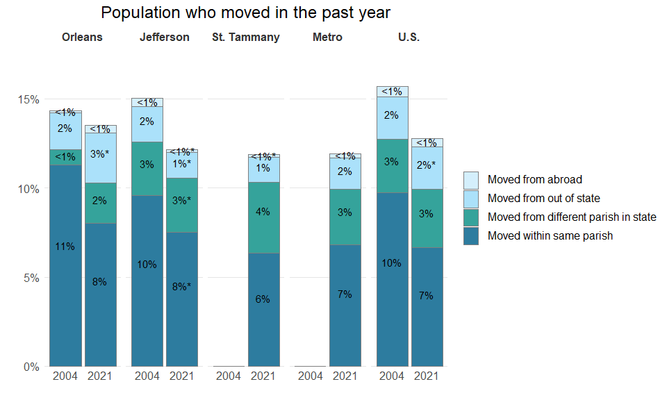

**Notes**: Share not included in the bar chart represents the population who lived in the same house one year ago (non-movers). For people living in the same house as a year ago, the difference between 2004 and 2021 is not significant at the 95% confidence interval for Orleans Parish. It is significant for all other geographies

**Notes**: Also, 2004 data is not available for St. Tammany Parish.

∗ = Difference between 2004 and 2021 is not significant at 95% confidence interval.

**Source**: The Data Center analysis of U.S. Census Bureau data from American Community Survey 2004 and 2021.

## Homeownership

Homeownership rates across the U.S. have fallen since 2000 from 66 to 65 percent in 2021. Homeownership rates have held steady in St. Tammany around 80 percent since 2000. In contrast, homeownership rates in New Orleans have increased slightly, but remain lower than neighboring parishes at 53 percent.

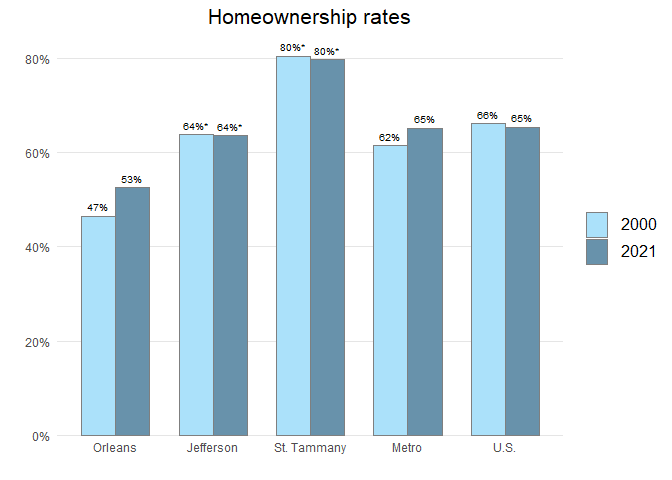

∗ = Difference between 2000 and 2021 is not significant at 95% confidence interval.

**Source**: The Data Center analysis of U.S. Census Bureau data from Census 2000 SF1 and American Community Survey 2021.

Homeownership rates among Black householders in New Orleans made consistent progress between 1970 and 2021, increasing from 27 percent to 46 percent. Still, the difference in homeownership rates between Black and White people in 2021 was significant, with only 46 percent of Black householders in New Orleans owning their homes compared to 63 percent of White householders.

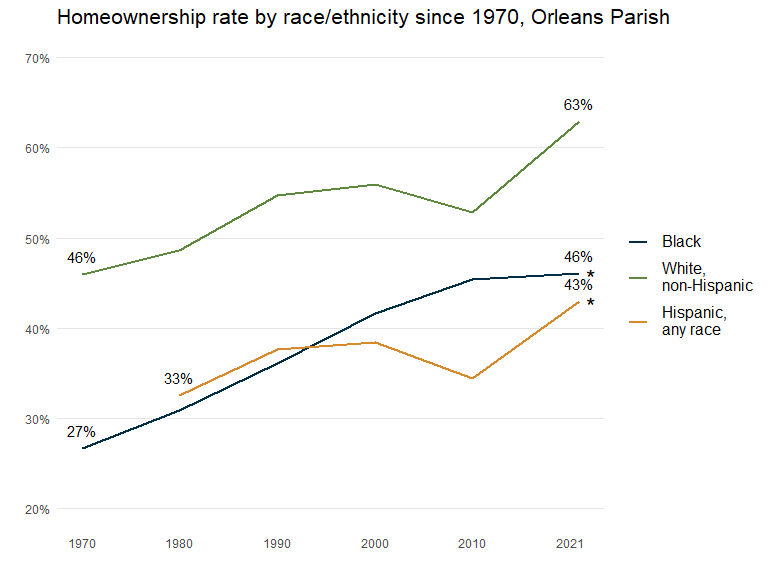

**Notes**: The number of Asians in New Orleans during the timespan of this chart is too small to produce reliable statistics. 1970 and 1980 data for White homeownership is inclusive of Hispanic people (due to data source limitations).  
∗ = Change in time is not significant for Black for 2010-2021.  
∗ = Change in time is not significant for Hispanic,any race for 2000-2021.

**Source**: The Data Center analysis of U.S. Census Bureau data from 1980, 1990, 2000 SF1, and 2010 and American Community Survey 2021.

Metro homeownership rates mirror national rates, with just over 65 percent of all householders owning their homes and White homeownership rates about 27 percentage points higher than rates for Black homeownership. This disparity is smaller in Orleans Parish, where only 63 percent of White householders own their homes. Homeownership in St. Tammany outstrips Orleans, Jefferson, and the metro overall, with 80 percent of all householders owning their home: a rate of 61 percent for Black householders, 84 percent for White householders, and 73 percent for Hispanic householders.

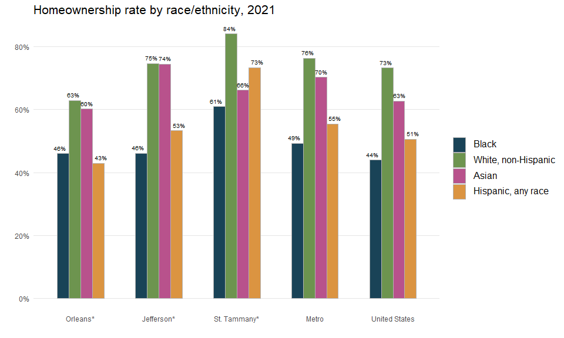

∗ = In Orleans Parish, the difference between White and Asian, Black and Hispanic, and Black and Asian is not statistically significant.  
∗ = In Jefferson Parish, the difference between White and Asian is not statistically significant.  
∗ = In St. Tammany Parish, the difference between White and Asian, White and Hispanic, Black and Hispanic, Black and Asian, and Hispanic and Asian is not statistically significant.

**Source**: The Data Center analysis of U.S. Census Bureau data from American Community Survey 2021.

Homeowners without a mortgage own their homes free and clear of any type of loan. A high share of such homeowners usually indicates residents living in the same house for long periods of time and helps shield neighborhoods from foreclosures. The proportion of metro area homeowners without a mortgage has increased from 35 to 43 percent between 2000 and 2021, driven by changes in Orleans and Jefferson. The share of homeowners without a mortgage jumped from 33 to 43 percent in Orleans and from 35 to 45 percent in Jefferson. One reason for the surge may be that homeowners who returned after Katrina used insurance or Road Home proceeds to pay off their mortgage principal. In fact, Orleans and Jefferson received the first and second largest number of Road Home Option 1 Grants among all Louisiana parishes.[^14]

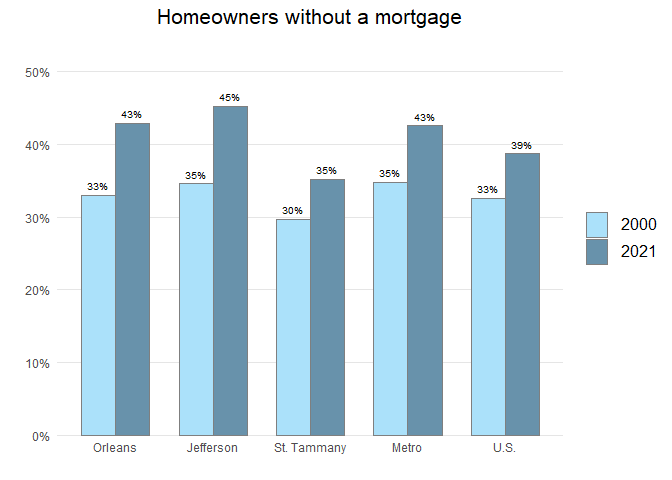

**Source**: The Data Center analysis of U.S. Census Bureau data from Census 2000 SF3 and American Community Survey 2021.

## Housing costs and affordability, housing stock, and commuting

High housing costs can limit a region’s ability to attract and retain the workforce essential for a healthy economy.[^15] Severe housing cost burdens of more than 50 percent of household income indicate a serious problem in housing affordability. In 2004, the share of severely cost-burdened renters in New Orleans and the U.S. was 23 and 22 percent, respectively. In the 17 years since, that share has spiked to 37 percent in Orleans while growing to only 26 percent nationally. In Jefferson Parish, the share of renters paying more than 50 percent of household income on housing and utilities is 29 percent in 2021.

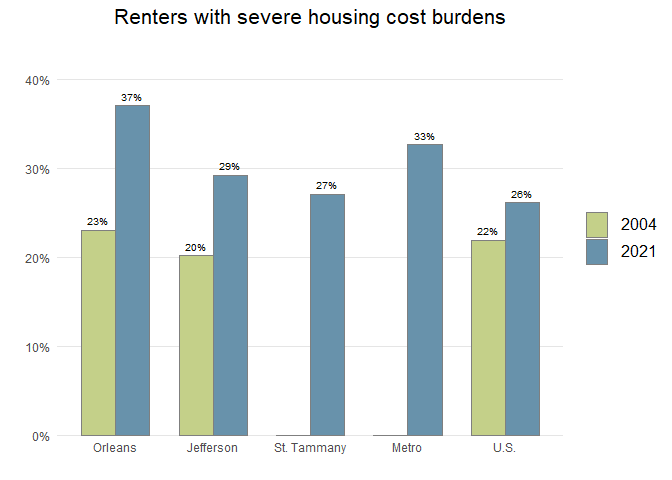

**Notes**: 2004 data is not available for St. Tammany Parish

**Source**: The Data Center analysis of U.S. Census Bureau data from American Community Survey 2004 and 2021.

The share of homeowners paying more than 50 percent of household income on their mortgage, taxes, utilities, and insurance is only 11 percent across the metro area. There is a clear gap between the rate of housing cost burden for renters vs. homeowners, and that gap has widened.

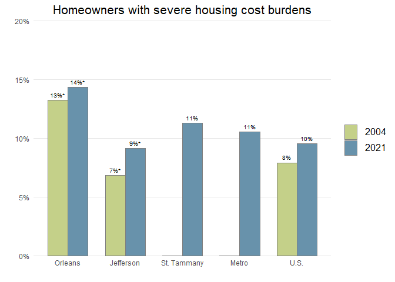

**Notes**: 2004 data is not available for St. Tammany Parish

∗ = Difference between 2004 and 2021 is not significant at 95% confidence interval.

**Source**: The Data Center analysis of U.S. Census Bureau data from American Community Survey 2004 and 2021.

The surge in the share of severely cost-burdened renters in New Orleans is reflective of the surge in the median gross rent (rent plus utilities) in the city. From 2004 to 2021, monthly rent plus utilities rose from $798 to $1,082 in New Orleans, a 36 percent increase after adjusting for inflation. Meanwhile, median gross rents increased 22 percent nationwide.

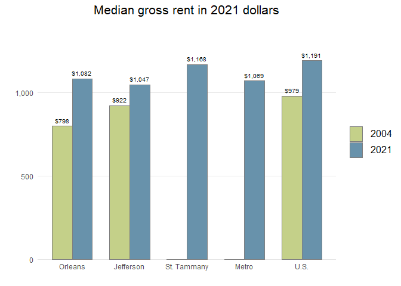

**Notes**: 2004 data is not available for St. Tammany Parish

**Source**: The Data Center analysis of U.S. Census Bureau data from American Community Survey 2004 and 2021.

America’s aging housing stock represents both a potential problem and an opportunity. Older homes are less energy-efficient and more expensive to maintain.[^16] Moreover, research has shown that lead poisoning in children is correlated strongly with residing in pre-1950 homes.[^17] Conversely, in New Orleans, many older homes are protected by preservation laws that have helped retain the historic character of the city.

In Orleans Parish, fully 38 percent of all housing units are in pre-1950 structures. Meanwhile, in Jefferson Parish, 72 percent of the housing stock was built in the 1950s, 1960s, 1970s, and 1980s, and just 20 percent of housing stock has been built since 1990. In contrast, in St. Tammany, the majority of housing units are in structures that have been built since 1990.

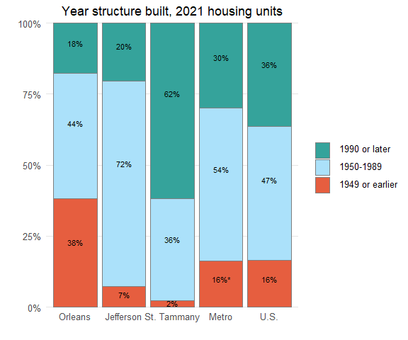

∗ = Difference between indicated measure and the U.S. is not significant at 95% confidence interval.

**Source**: The Data Center analysis of U.S. Census Bureau data from American Community Survey 2021.

A metro region is partially defined by the commuting patterns of its residents. Commuting has been studied more and more as the costs and burdens (physical, mental, familial, etc.) are uncovered.

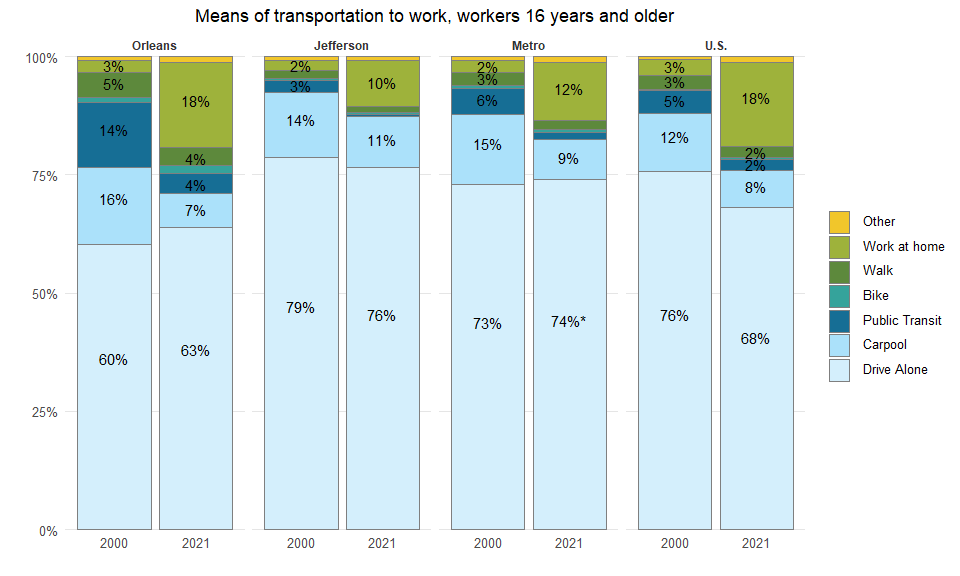

∗ = Difference between 2000 and 2021 is not significant at 95% confidence interval.

**Source**: The Data Center analysis of U.S. Census Bureau data from Census 2000 SF3 and American Community Survey 2021.

## Data Sources / Methodology

Data on race/ethnicity and age is from the Census Bureau vintage 2021 population estimates and Census 2000 Summary File 1 (SF1). Other demographic data is from the Census 2000 Summary File 3 (SF3) and American Community Survey 2004, and 2021 (single-year files).

Statistical tests of significance were computed at the 95% confidence level for all data from the American Community Survey and Census 2000 SF3. An “*” indicates that differences between two time periods or geographies are not significant, and therefore are the result of sampling variability rather than real change in characteristics of the population.

The significance tests require both estimates and their standard errors. Standard errors for the ACS estimates were calculated using formulas from section 7, “Understanding Error and Determining Statistical Significance” available at: https://www.census.gov/content/dam/Census/library/publications/2018/acs/acs_general_handbook_2018.pdf.

Standard errors for Census 2000 SF3 data were calculated using formulas from Chapter 8 of the Technical Documentation available at: https://www2.census.gov/programs-surveys/decennial/2000/technical-documentation/complete-tech-docs/summary-files/sf3.pdf.

Standard errors for Census 2000 and Census 2010 SF1 data are zero.

## Endnotes

[^1]: The eight-parish New Orleans metro includes Jefferson, Orleans, Plaquemines, St. Bernard, St. Charles, St. James, St. John the Baptist, and St. Tammany. From 2003-2012, the New Orleans metro was comprised of 7 parishes, excluding St. James. This brief has updated all 2000 metro data to reflect an 8-parish definition, however previous versions of this report will have used the 7-parish metro definition and accompanying numbers.
[^2]: Throughout this brief, when referring to Population Estimates and Projections data, “African American/Black,” “Asian,” and “White” refer to individuals who report to be only one race and not Hispanic. However, “Hispanics” can be of any race(s). When using American Community Survey data, “African American/Black” and “Asian” are inclusive of “Hispanics”.
[^3]: Taylor, P., Lopez M. H., Martinez, J., and Velasco, G. (2014). When Labels Don’t Fit: Hispanics and Their Views of Identity. Retrieved October 3, 2014 from http://www.pewhispanic.org/2012/04/04/when-labels-dont-fit-hispanics-and-their-views-of-identity.
[^4]: Plyer, A. and Ortiz, E. (2011). Drivers of housing demand: Preparing for the impending elder boom. Retrieved July 8, 2013 from http://www.datacenterresearch.org/reports_analysis/drivers-of-housing-demand.
[^5]: Julian, T. and Kominski, R. (2011). Education and synthetic work-life earnings estimates. Retrieved February 8, 2021 from https://www.census.gov/library/publications/2011/acs/acs-14.html; U.S. Department of Housing and Urban Development. (2012). Conceptualizing and measuring resilience. Retrieved September 18, 2012 from http://www.huduser.org/portal/periodicals/em/winter12/highlight2.html#title.
[^6]: Plyer, A. and Gardere, L. (2018), The New Orleans Prosperity Index: Tricentennial Edition. Retrieved October 17, 2022 from https://s3.amazonaws.com/gnocdc/reports/ProsperityIndex.pdf.
[^7]: Vigdor J. and Ladd, H. (2010). Scaling the Digital Divide: Home Computer Technology and Student Achievement. Retrieved February 8, 2021 from http://citeseerx.ist.psu.edu/viewdoc/download?doi=10.1.1.849.6663&rep=rep1&type=pdf.
[^8]: Difference between Black and Hispanic not statistically significant at a 95% confidence level.
[^9]: De Jong, G.F., Graefe, D.R., Hall, M., and Singer, A. (2001). The geography of immigrant skills: Educational profiles of metropolitan areas. Retrieved February 8, 2021 from https://www.brookings.edu/research/the-geography-of-immigrant-skills-educational-profiles-of-metropolitan-areas/.
[^10]: Difference between Black and Hispanic not statistically significant at a 95% confidence level.
[^11]: De Jong, G.F., Graefe, D.R., Hall, M., and Singer, A. (2001). The geography of immigrant skills: Educational profiles of metropolitan areas. Retrieved February 8, 2021 from https://www.brookings.edu/research/the-geography-of-immigrant-skills-educational-profiles-of-metropolitan-areas/.
[^12]: Based on surveys conducted by the U.S. Census Bureau, employment-related reasons are the most frequent reason for inter-county moves of greater than 50 miles. For example, among people in the United States who moved over 500 miles, 52 percent moved for an employment-related reason compared to 23 percent for a family-related reason and 22 percent for a housing-related reason. Employment-related reasons include a new job or job transfer, to look for work, to be closer to work, retirement, and other job-related reasons. See U.S. Census Bureau. (n.d.). Geographic Mobility: 2011 to 2012 (Table 27). Retrieved February 8, 2021 from https://www.census.gov/topics/population/migration/data/tables/cps.2012.html.
[^13]: Based on surveys conducted by the U.S. Census Bureau, people 25 to 29 years old were more likely than other age groups to be movers from a different county, state, region, or country. And people with a professional or graduate degree were also more likely than other educational groups to be movers from a different county, state, region, or country. See U.S. Census Bureau. (n.d.). Geographic Mobility: 2011 to 2012 (Table 1). Retrieved September 23, 2013 from https://www.census.gov/topics/population/migration/data/tables/cps.2012.html.
[^14]: State of Louisiana Office of Community Development. (2013). The Homeowner Assistance Program Week 375 Situation & Pipeline Report.
[^15]: Plyer, A., Ortiz, E., and Pettit, K. (2009). Post-Katrina housing affordability challenges continue in 2008, worsening among Orleans Parish very low income renters. Retrieved September 17, 2013 from http://www.datacenterresearch.org/reports_analysis/housing-affordability.
[^16]: Joint Center for Housing Studies of Harvard University (2013). The US Housing Stock: Ready for Renewal. Retrieved October 10, 2014 from http://www.jchs.harvard.edu/sites/jchs.harvard.edu/files/harvard_jchs_remodeling_report_2013.pdf.
[^17]: Roberts, J.R., Hulsey, T.C., Curtis, G.B., and Reigart, J.R. (2003). Using Geographic Information Systems to Assess Risk for Elevated Blood Lead Levels in Children. Retrieved October 10, 2014 from http://www.ncbi.nlm.nih.gov/pmc/articles/PMC1497528/pdf/12766217.pdf.